# Weight Lifting Exercise Prediction

Tim Sloan

15 January 2016

# Executive summary

The [Weight Lifting Exercises Dataset](http://groupware.les.inf.puc-rio.br/har) was collected from participants wearing sensors during a weight training session. Data are labelled according to whether the exercises were performed correctly or not. After tidying up the data, 52 variables were identified, representing measurements from the arm, forearm, belt and dumbbell for the following sensor values: roll, pitch, yaw, magnet(xyz), gyros(xyz), acceleration(xyz) and total acceleration. Exploratory analysis suggested that the belt sensors, excluding gyros, may be more discriminatory than other variables, but that the majority of variables appeared to be providing useful information.

Given the minimal impact on accuracy, but potential gains in performance, the 26 variable random forest model was selected for use on the test set with 98% accuracy as expected and then deployed on the 20 question quiz with 100% success.

# Data cleaning

The required libraries were loaded and datasets downloaded from the URL provided.

```r
library(dplyr)
library(caret)
```

```r
library(ggplot2)
library(parallel)
library(doParallel)
if(!file.exists("weight_train.csv")){
        download.file("https://d396qusza40orc.cloudfront.net/predmachlearn/pml-training.csv","weight_train.csv")
}
if(!file.exists("weight_test.csv")){
        download.file("https://d396qusza40orc.cloudfront.net/predmachlearn/pml-testing.csv","weight_test.csv")
}

wt_train <- read.csv("weight_train.csv",na.strings=c("","NA"))
wt_test <- read.csv("weight_test.csv",na.strings=c("","NA"))
```

Several variables were found to mostly contain missing data, with only summary values for aggregated value windows. These were removed, along with the subject and time variables so that solely the sensor data could be used to train the model. This was constrained by the format of the test data for the assignment, which requires testing on individual values, not the entire exercise window as used by the dataset authors for their publication.

Tabulating the final 52 values shows the 12 individual values for each position (arm, forearm, belt and dumbbell) along with the four total acceleration values for each position. The 12 values were: roll, pitch, yaw, accel(xyz), magnet(xyz) and gyros(xyz).

```r
na.fields <- lapply(wt_train, function(x) {sum(is.na(x))})
rm.na <- wt_train[na.fields==0]
tidy <- select(rm.na, -c(1:7))

labels <- as.factor(sapply(names(tidy), function(x) {strsplit(x,"_")[[1]][2]}))[1:52]
table(labels) #roll, pitch, yaw, accel(xyz), magnet(xyz), gyros(xyz), totel_accel = 13 * 4 (arm, forearm, belt, dumbbell)
```

```
## labels
##    accel      arm     belt dumbbell  forearm
##        4       12       12       12       12
```

# Data partitions

60% of the data was reserved for model training, a further 20% for cross-validation and algorithm selection and a final 20% for testing the optimal algorithm and estimation of the out of sample error rate.

```r
set.seed(32323)
part <- createDataPartition(tidy$classe, p=0.6, list=FALSE)
train <- tidy[part,]
heldout <- tidy[-part,]
part2 <- createDataPartition(heldout$classe, p=0.5, list=FALSE)
cv <- heldout[part2,]
test <- heldout[-part2,]

rm(list=c("wt_train","rm.na","tidy","part","part2","heldout")) #tidy up workspace
```

# Exploratory data analysis

Variables were analysed to look for promising candidates. None of the variables exhibited zero-variance, and as shown in figure 1, the vast majority were uncorrelated or weakly correlated.

```r
table(sapply(train[,-53],var)>0.001)
```

```
##
## TRUE
##   52
```

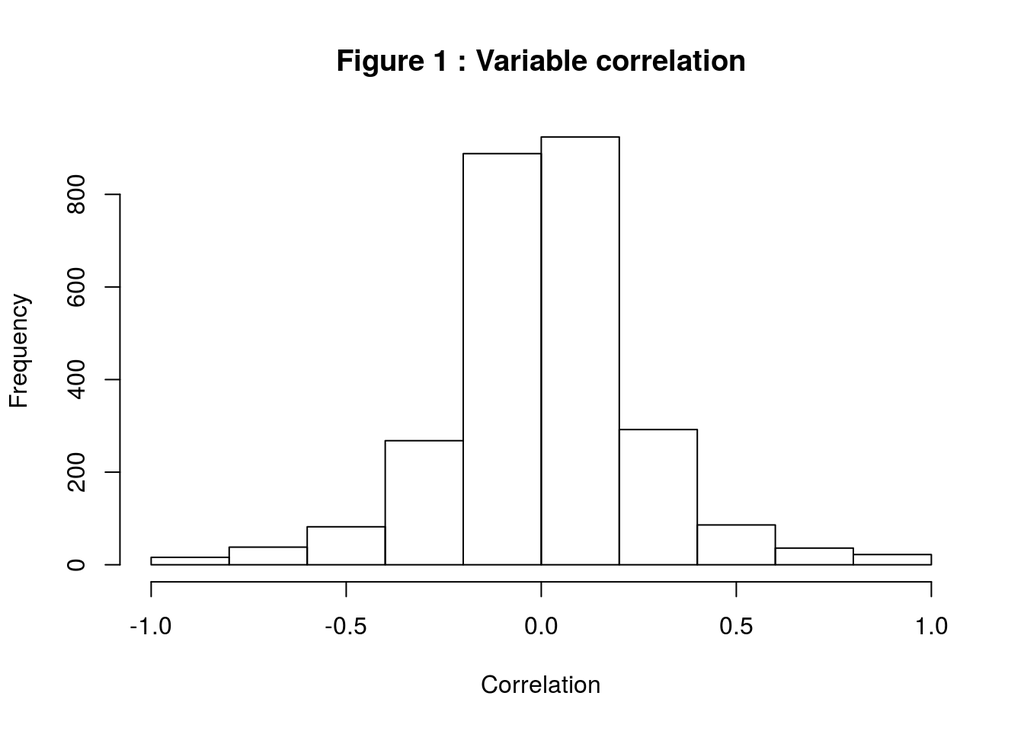

```r
scaled <- scale(train[,-53])
corr <- cor(scaled)
hist(corr[corr<1], main = "Figure 1 : Variable correlation",xlab="Correlation")
```

In an attempt to look for variables which distinguished well between the exercise classes, the data was scaled to uniform mean and SD, and the widest gap between class medians was calculated for each variable. This indicated that many of the gyros sensor readings appeared to discriminate poorly between classes, where as other values, particularly belt acceleration and arm magnets appeared to discriminate well.

```r
mdif <- sapply(data.frame(scaled), function(x){
    temp <- tapply(x, train$classe, median)
    (max(temp) - min(temp))
})

mdif[mdif<0.2]
```

```
##          pitch_belt        gyros_belt_x        gyros_belt_y
##          0.03343202          0.09740750          0.00000000
##             yaw_arm         gyros_arm_x    gyros_dumbbell_x
##          0.00000000          0.12059989          0.01561303
##    gyros_dumbbell_y    gyros_dumbbell_z total_accel_forearm
##          0.08829128          0.00680292          0.19796747
##     gyros_forearm_x     gyros_forearm_y     gyros_forearm_z
##          0.12227609          0.02791820          0.06791960
```

```r
mdif[mdif>1.0]
```

```
##        roll_belt         yaw_belt total_accel_belt     accel_belt_y
##         1.993985         1.024730         1.550679         1.225695
##     accel_belt_z    magnet_belt_z      accel_arm_x     magnet_arm_x
##         1.742382         1.125596         1.358505         1.802286
##     roll_forearm magnet_forearm_x
##         1.186608         1.228499
```

## Figure 2: Variables with a large and small range of class medians

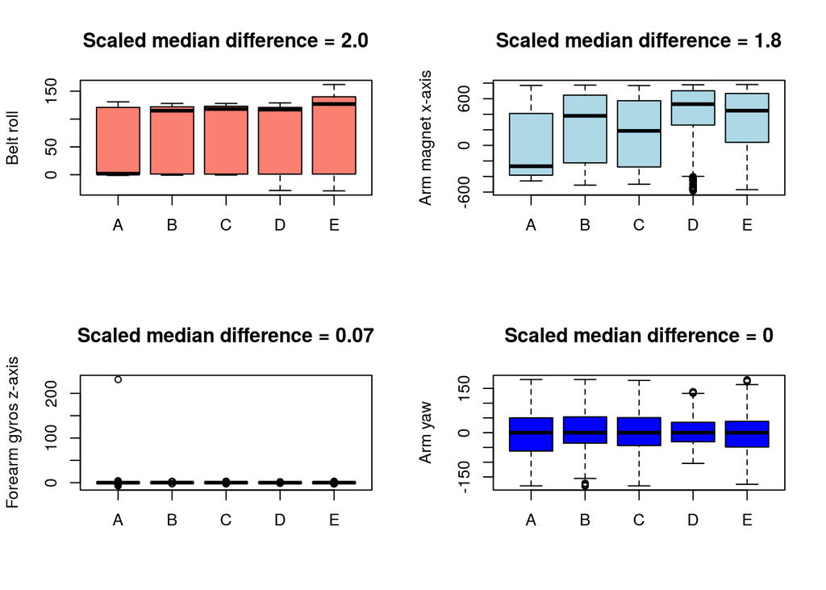

```r
par(mfrow=c(2,2))
boxplot(data=train, roll_belt~classe, ylab="Belt roll", col="salmon", main="Scaled median difference = 2.0")
boxplot(data=train, magnet_arm_x~classe, ylab="Arm magnet x-axis", col="light blue", main="Scaled median difference = 1.8")
boxplot(data=train, gyros_forearm_z~classe, ylab="Forearm gyros z-axis", col="blue", main="Scaled median difference = 0.07")
boxplot(data=train, yaw_arm~classe, ylab="Arm yaw", col="blue", main="Scaled median difference = 0")
```

```r
mini_train <- train[,mdif>1]
midi_train <- train[,mdif>0.42]
```

Before beginning to train the models, PCA analysis was also conducted to look at the variance in the data. As shown in figure 3, the first two principal components explained roughly 15% of the variance each, for a total of 30%. PC1 seemed to discriminate better between classes. Plotting the variable weighting for PC1 coloured by sensor position appeared to indicate that the arm and belt sensors had the largest positive and negative weightings on PC1. The potential importance of the belt sensors is consistent with the analysis above.

## Figure 3: Results of Principal Components Analysis

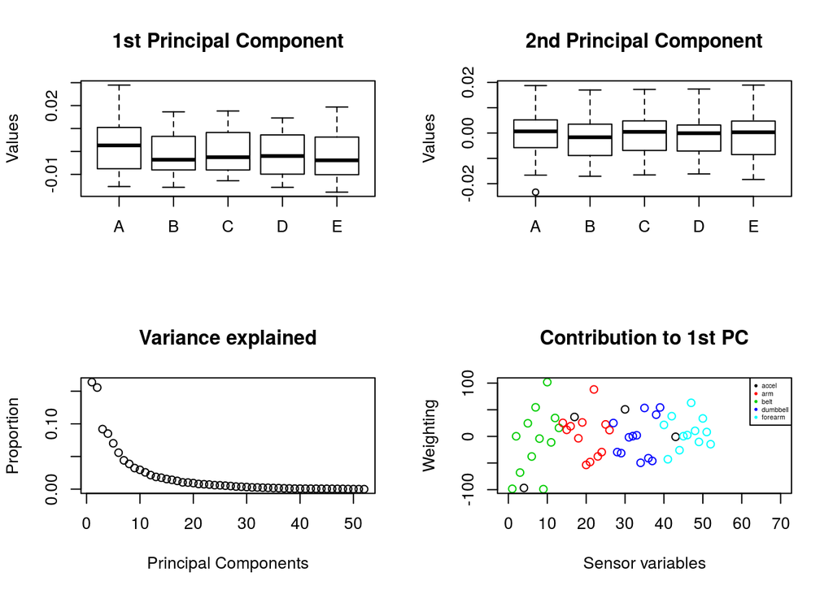

```r
pca <- prcomp(t(scaled))

par(mfrow=c(2,2))
plot(train$classe, pca$rotation[,1], ylab="Values",main="1st Principal Component")
plot(train$classe, pca$rotation[,2], ylab="Values",main="2nd Principal Component")
plot(pca$sdev^2/sum(pca$sdev^2), ylab="Proportion",xlab="Principal Components",main="Variance explained")
plot(pca$x[,1], col=labels, ylab="Weighting", xlab="Sensor variables",main="Contribution to 1st PC",xlim=c(0,70))
legend("topright", legend=levels(labels), pch=20, col=c(1:5), cex=0.4)
```

# Model selection

Three algorithms were initially tested against all 52 variables from the training data. Random forest and schochastic gradient boosting were chosen as these algorithms are widely used and perform well for most applications. Linear discriminant analysis was also tested as a lighter weight and quicker to train algorithm. Because of slow training times for the random forest model, the following code makes use of parallel processing to speed up training. k-fold cross validation was also used for estimation of the model error rate, rather than bootstrapping, as this also greatly speeds up training time.

```r
clusters <- makeCluster(detectCores()-1)
registerDoParallel(clusters)

tr_params <- trainControl(method="cv",number=10,allowParallel = TRUE)

# Train models
modelFit <- train(train$classe~.,method="rf",data=train,trControl=tr_params) #99%
modelFit2 <- train(train$classe~.,method="lda",data=train,trControl=tr_params) #71%
modelFit3 <- train(train$classe~.,method="gbm",data=train,trControl=tr_params,verbose=FALSE) #96%

stopCluster(clusters)

# Test models on cross validation data
results <- predict(modelFit, newdata=cv)
results2 <- predict(modelFit2, newdata=cv)
results3 <- predict(modelFit3, newdata=cv)

# Generate confusion matrices and estimate accuracy
confusionMatrix(cv$classe, results)$overall[1] # random forest 99%
```

```
##  Accuracy
## 0.9908233
```

```r
confusionMatrix(cv$classe, results2)$overall[1] # linear discriminant analysis 70%
```

```
##  Accuracy
## 0.6971705
```

```r
confusionMatrix(cv$classe, results3)$overall[1] # stochastic gradient boosting 96%
```

```
## Accuracy
##  0.95896
```

```r
clusters <- makeCluster(detectCores()-1)
registerDoParallel(clusters)

modelFit4 <- train(train$classe~.,method="rf",data=train,trControl=tr_params, preProcess="pca") #96%
modelFit5 <- train(train$classe~., method="rf", data=mini_train, trControl=tr_params) #95%
modelFit6 <- train(train$classe~., method="rf", data=midi_train, trControl=tr_params) #98%

stopCluster(clusters)

results4 <- predict(modelFit4, newdata=cv)
results5 <- predict(modelFit5, newdata=cv)
results6 <- predict(modelFit6, newdata=cv)

confusionMatrix(cv$classe, results4)$overall[1] # rf with pca 98%
```

```
##  Accuracy
## 0.9770584
```

```r
confusionMatrix(cv$classe, results5)$overall[1] # rf with 11 variables 96%
```

```
##  Accuracy
## 0.9581953
```

```r
confusionMatrix(cv$classe, results6)$overall[1] # rf with 26 variables 99%
```

```
## Accuracy
## 0.983431
```

```r
final <- predict(modelFit6, newdata=test)
confusionMatrix(test$classe, final) #98.4%
```

```
## Confusion Matrix and Statistics
##
##           Reference
## Prediction    A    B    C    D    E
##          A 1112    4    0    0    0
##          B    7  740    9    1    2
##          C    0   15  665    4    0
##          D    0    2    8  633    0
##          E    0    2    5    4  710
##
## Overall Statistics
##
##                Accuracy : 0.9839
##                  95% CI : (0.9795, 0.9876)
##     No Information Rate : 0.2852
##     P-Value [Acc > NIR] : < 2.2e-16
##
##                   Kappa : 0.9797
##  Mcnemar's Test P-Value : NA
##
## Statistics by Class:
##
##                      Class: A Class: B Class: C Class: D Class: E
## Sensitivity            0.9937   0.9699   0.9680   0.9860   0.9972
## Specificity            0.9986   0.9940   0.9941   0.9970   0.9966
## Pos Pred Value         0.9964   0.9750   0.9722   0.9844   0.9847
## Neg Pred Value         0.9975   0.9927   0.9932   0.9973   0.9994
## Prevalence             0.2852   0.1945   0.1751   0.1637   0.1815
## Detection Rate         0.2835   0.1886   0.1695   0.1614   0.1810
## Detection Prevalence   0.2845   0.1935   0.1744   0.1639   0.1838
## Balanced Accuracy      0.9962   0.9819   0.9811   0.9915   0.9969
```

```r
test_result <- predict(modelFit6, newdata=wt_test) #100% on quiz
test_result
```

```
##  [1] B A B A A E D B A A B C B A E E A B B B
## Levels: A B C D E
```